# bank_churn

```python
import pandas as pd
import numpy as np
import matplotlib.pyplot as plt
import seaborn as sns
sns.set()
```

```python
df = pd.read_csv("Bank Customer Churn Prediction.csv")
```

```python
df['churn'].value_counts()/df.shape[0]
```

```
0    0.7963
1    0.2037
Name: churn, dtype: float64
```

We have imbalanced classes. The positive class (represented by 1, ie, customer did leave) is the minority class. Due to absense of problem statement, we'll assume that its more important we don't miss the ones who will leave the bank. So, the metric to focus on here is recall.

```python
df.head()
```

|  | customer_id | credit_score | country | gender | age | tenure | balance | products_number | credit_card | active_member | estimated_salary | churn |
| --- | --- | --- | --- | --- | --- | --- | --- | --- | --- | --- | --- | --- |
| 0 | 15634602 | 619 | France | Female | 42 | 2 | 0.00 | 1 | 1 | 1 | 101348.88 | 1 |
| 1 | 15647311 | 608 | Spain | Female | 41 | 1 | 83807.86 | 1 | 0 | 1 | 112542.58 | 0 |
| 2 | 15619304 | 502 | France | Female | 42 | 8 | 159660.80 | 3 | 1 | 0 | 113931.57 | 1 |
| 3 | 15701354 | 699 | France | Female | 39 | 1 | 0.00 | 2 | 0 | 0 | 93826.63 | 0 |
| 4 | 15737888 | 850 | Spain | Female | 43 | 2 | 125510.82 | 1 | 1 | 1 | 79084.10 | 0 |

```python
df.shape
```

```
(10000, 12)
```

```python
def data_preprocessor(df):
    df = df.drop('customer_id',axis=1)
    df['gender'] = df['gender'].replace({'Female':1,'Male':0})
    return df
```

```python
df = data_preprocessor(df)
```

```python
num_cols = df.columns.tolist()
num_cols.remove('churn')
num_cols.remove('country')
cat_cols = ['country']
```

# Plotting the features

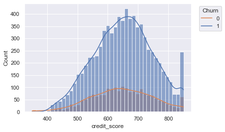

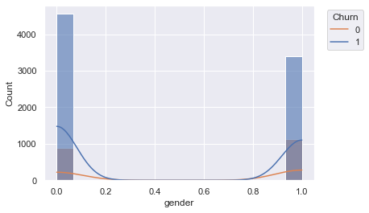

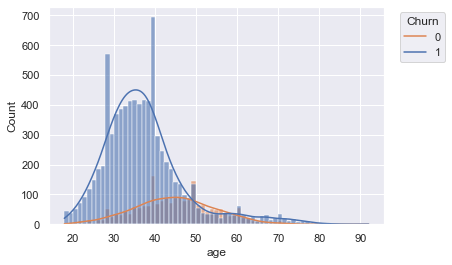

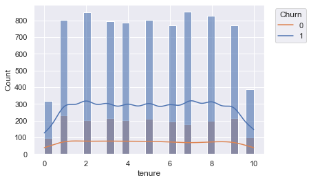

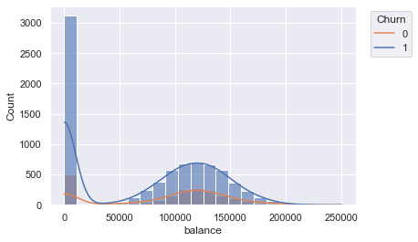

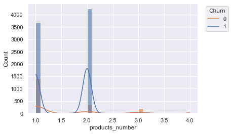

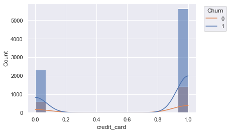

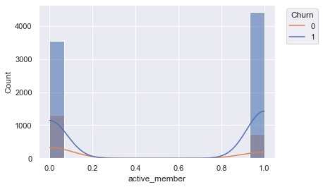

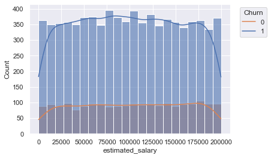

```python
for i in num_cols:
    sns.histplot(data=df,x=i,hue='churn',alpha=0.6,kde=True)
    plt.xlabel(i)
    plt.legend(['0','1'],title='Churn',bbox_to_anchor=(1.2,1))
    plt.show()
```

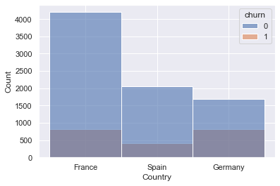

```python
sns.histplot(data=df,x='country',hue='churn',alpha=0.6)
plt.xlabel('Country')
plt.show()
```

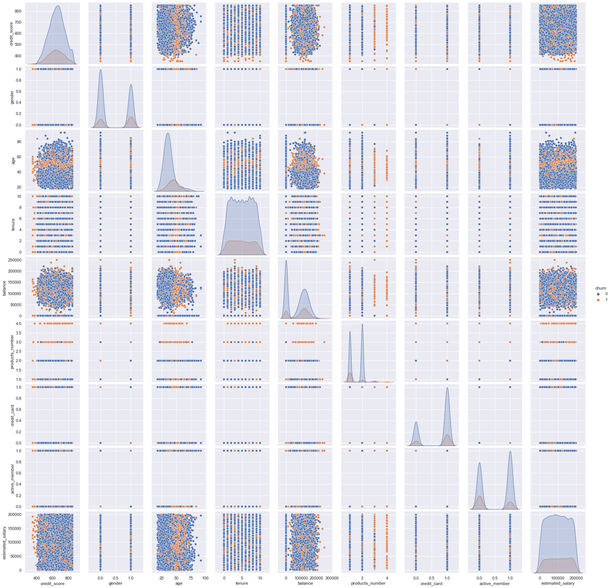

```python
sns.pairplot(df.drop('country',axis=1),hue='churn')
plt.show()
```

products_number and age stand out showing some class separation.

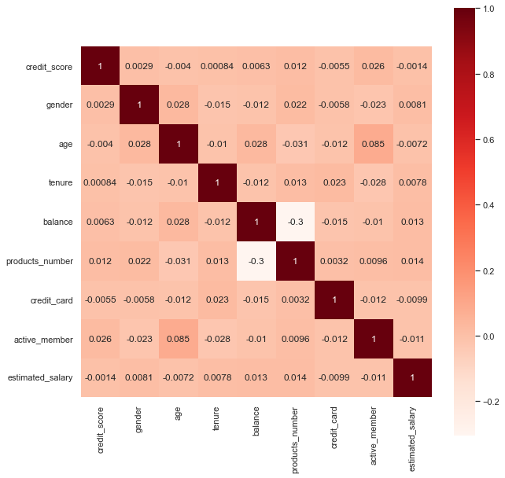

```python
corr = df.drop(['country','churn'],axis=1).corr()
fig,ax = plt.subplots(figsize=(10,10))
sns.heatmap(corr,square=True,cmap='Reds',cbar=True,annot=True,ax=ax)
plt.show()
```

For most part, the features don't show much correlation

# Model Fitting

```python
from sklearn.preprocessing import OneHotEncoder, MinMaxScaler
from sklearn.model_selection import train_test_split

trainX, testX, trainY, y_test = train_test_split(df.drop('churn',axis=1),df['churn'],test_size=0.2,random_state=2)
```

```python
X_num_train = trainX[num_cols]
X_cat_train = trainX['country']

scaler = MinMaxScaler()
scaler.fit(X_num_train)

ohe = OneHotEncoder()
ohe.fit(X_cat_train.values.reshape(-1,1))

def data_transformer(X):
    X_num = X[num_cols]
    X_cat = X['country'].values.reshape(-1,1)

    X_num = scaler.transform(X_num)
    X_cat = ohe.transform(X_cat).toarray()
    return np.concatenate((X_num,X_cat),axis=1)

X_train = data_transformer(trainX)
X_test = data_transformer(testX)

y_train = trainY.values
y_test = y_test.values
```

```python
from sklearn.metrics import recall_score, accuracy_score
from sklearn.svm import SVC
from sklearn.naive_bayes import GaussianNB
from sklearn.linear_model import SGDClassifier
from sklearn.tree import DecisionTreeClassifier
from sklearn.ensemble import RandomForestClassifier
from sklearn.ensemble import AdaBoostClassifier
from sklearn.ensemble import GradientBoostingClassifier
from xgboost import XGBClassifier
from lightgbm import LGBMClassifier
from catboost import CatBoostClassifier
```

```python
classifiers = [SVC(kernel='rbf'),
               GaussianNB(),
               SGDClassifier(),
               DecisionTreeClassifier(),
               RandomForestClassifier(),
               AdaBoostClassifier(),
               GradientBoostingClassifier(),
               XGBClassifier(use_label_encoder=False),
               LGBMClassifier(),
               CatBoostClassifier(verbose=False)]

scores_df = pd.DataFrame(columns=['Classifier','TestRecall','TestAccuracy','TrainRecall','TrainAccuracy'])

for i in classifiers:
    i.fit(X_train,y_train)
    y_pred_test = i.predict(X_test)
    y_pred_train = i.predict(X_train)
    scores_df.loc[len(scores_df.index)] = [i.__class__.__name__,
                                           recall_score(y_test,y_pred_test),accuracy_score(y_test,y_pred),
                                           recall_score(y_train,y_pred_train),accuracy_score(y_train,y_pred_train)]
```

```
[07:14:15] WARNING: C:\Windows\Temp\abs_557yfx631l\croots\recipe\xgboost-split_1659548953302\work\src\learner.cc:1115: Starting in XGBoost 1.3.0, the default evaluation metric used with the objective 'binary:logistic' was changed from 'error' to 'logloss'. Explicitly set eval_metric if you'd like to…
```

```python
scores_df.sort_values(by='TestRecall')
```

|  | Classifier | TestRecall | TestAccuracy | TrainRecall | TrainAccuracy |
| --- | --- | --- | --- | --- | --- |
| 2 | SGDClassifier | 0.002611 | 0.859 | 0.001814 | 0.792750 |
| 0 | SVC | 0.224543 | 0.859 | 0.299879 | 0.845625 |
| 1 | GaussianNB | 0.328982 | 0.859 | 0.381499 | 0.818000 |
| 7 | XGBClassifier | 0.415144 | 0.859 | 0.809553 | 0.956125 |
| 5 | AdaBoostClassifier | 0.417755 | 0.859 | 0.495163 | 0.858375 |
| 6 | GradientBoostingClassifier | 0.428198 | 0.859 | 0.513301 | 0.874875 |
| 4 | RandomForestClassifier | 0.433420 | 0.859 | 1.000000 | 1.000000 |
| 9 | CatBoostClassifier | 0.441253 | 0.859 | 0.634825 | 0.910875 |
| 8 | LGBMClassifier | 0.443864 | 0.859 | 0.654776 | 0.915500 |
| 3 | DecisionTreeClassifier | 0.480418 | 0.859 | 1.000000 | 1.000000 |

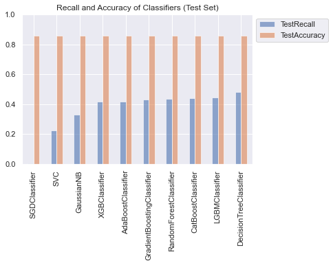

```python
scores_df.sort_values(by='TestRecall').plot.bar(x='Classifier',y=['TestRecall','TestAccuracy'],alpha=0.6)
plt.legend(bbox_to_anchor=(1,1))
plt.title('Recall and Accuracy of Classifiers (Test Set)')
plt.xlabel(None)
plt.ylim(0,1)
plt.show()
```

DecisionTree overfitting as usual.

# Oversampling the Minority Class

```python
traindf = pd.concat([trainX,trainY],axis=1)

n0, n1 = traindf['churn'].value_counts() #number of instances in each class

class0 = traindf[traindf['churn']==0]
class1 = traindf[traindf['churn']==1]
```

```python
print("Before Resampling")
print("Fraction of Class 1: {}".format(n1/(n0+n1)))
#We'll boost % of class 1 from 14% to ~40% of total
#taking 3*n1 samples gives ~44% of total

class1over = class1.sample(3*n1,replace=True)
overdf = pd.concat([class0,class1over],axis=0).sample(frac=1)

print("After Resampling")
print("Fraction of Class 1: {}".format(overdf['churn'].value_counts()[1]/overdf.shape[0]))
```

```
Before Resampling
Fraction of Class 1: 0.20675
After Resampling
Fraction of Class 1: 0.4388043862752034
```

```python
X_train = data_transformer(overdf.drop('churn',axis=1))
y_train = overdf['churn'].values
```

# Fitting models to dataset with over-sampled minority class

```python
scores_df_over =  pd.DataFrame(columns=['Classifier','TestRecall','TestAccuracy','TrainRecall','TrainAccuracy'])

for i in classifiers:
    i.fit(X_train,y_train)
    y_pred_test = i.predict(X_test)
    y_pred_train = i.predict(X_train)
    scores_df_over.loc[len(scores_df_over.index)] = [i.__class__.__name__,
                                           recall_score(y_test,y_pred_test),accuracy_score(y_test,y_pred),
                                           recall_score(y_train,y_pred_train),accuracy_score(y_train,y_pred_train)]
```

```
[07:39:35] WARNING: C:\Windows\Temp\abs_557yfx631l\croots\recipe\xgboost-split_1659548953302\work\src\learner.cc:1115: Starting in XGBoost 1.3.0, the default evaluation metric used with the objective 'binary:logistic' was changed from 'error' to 'logloss'. Explicitly set eval_metric if you'd like to…
```

```python
scores_df_over.sort_values(by='TestRecall')
```

|  | Classifier | TestRecall | TestAccuracy | TrainRecall | TrainAccuracy |
| --- | --- | --- | --- | --- | --- |
| 3 | DecisionTreeClassifier | 0.472585 | 0.859 | 1.000000 | 1.000000 |
| 4 | RandomForestClassifier | 0.475196 | 0.859 | 1.000000 | 1.000000 |
| 7 | XGBClassifier | 0.540470 | 0.859 | 0.968561 | 0.968695 |
| 1 | GaussianNB | 0.558747 | 0.859 | 0.610842 | 0.708348 |
| 0 | SVC | 0.584856 | 0.859 | 0.660419 | 0.784312 |
| 8 | LGBMClassifier | 0.587467 | 0.859 | 0.893591 | 0.908826 |
| 9 | CatBoostClassifier | 0.587467 | 0.859 | 0.898025 | 0.916873 |
| 2 | SGDClassifier | 0.618799 | 0.859 | 0.647924 | 0.708260 |
| 6 | GradientBoostingClassifier | 0.637076 | 0.859 | 0.732366 | 0.814556 |
| 5 | AdaBoostClassifier | 0.660574 | 0.859 | 0.707175 | 0.783870 |

[figure not shown]

```python
scores_df_over.sort_values(by='TestRecall').plot.bar(x='Classifier',y=['TestRecall','TestAccuracy'],alpha=0.6)
plt.legend(bbox_to_anchor=(1,1))
plt.title('Recall and Accuracy of Classifiers')
plt.xlabel(None)
plt.ylim(0,1)
plt.show()
```

Best model performance (before tuning) is increased by ~20% (wrt recall) In fact, for the best model (decision tree in first case) test accuracy was 85%, and now too, the best model (adaboost) has 85% test accuracy

We'll tune AdaBoostClassifier and LGBMClassifier

# Tuning Select Models

```python
from sklearn.model_selection import GridSearchCV
```

```python
def grid_search(model,param_grid,cv,X_train,X_test,y_train,y_test):
    gcv = GridSearchCV(model,param_grid,cv=cv,n_jobs=6,scoring='recall')
    gcv.fit(X_train,y_train)
    print("Model: %s"%model)
    y_pred_train = gcv.predict(X_train)
    y_pred_test = gcv.predict(X_test)
    print("Test Accuracy Score: %s"%accuracy_score(y_test,y_pred_test))
    print("Test Recall Score: %s"%recall_score(y_test,y_pred_test))
    print()
    print("Train Accuracy Score: %s"%accuracy_score(y_train,y_pred_train))
    print("Train Recall Score: %s"%recall_score(y_train,y_pred_train))
    print("Optimized Model Parameters: ")
    print(gcv.best_params_)
    return gcv
```

```python
#adaboost
param_grid = {'base_estimator':[DecisionTreeClassifier(max_depth=3)],
              'n_estimators':[50,75,100],
              'learning_rate':[0.6,0.8,1.0,1.2,1.4]}
cv=5
ada_opt = grid_search(AdaBoostClassifier(),param_grid,cv,
                      X_train, X_test, y_train, y_test)
```

```
Model: AdaBoostClassifier()
Test Accuracy Score: 0.796
Test Recall Score: 0.5378590078328982

Train Accuracy Score: 0.9084718783162363
Train Recall Score: 0.8937928254735994
Optimized Model Parameters:
{'base_estimator': DecisionTreeClassifier(max_depth=3), 'learning_rate': 1.2, 'n_estimators': 100}
```

All that doesn't give us a better test score. let's just have adaboost stick with its default settings

```python
#lgbm
param_grid = {'learning_rate':[0.1,0.11],
              'n_estimators':[110],
              'max_depth':[-1],
              'num_leaves':[31]}

cv=5
lgbm_opt = grid_search(LGBMClassifier(),param_grid,cv,
                      X_train, X_test, y_train, y_test)
```

```
Model: LGBMClassifier()
Test Accuracy Score: 0.833
Test Recall Score: 0.5900783289817232

Train Accuracy Score: 0.9157233816766891
Train Recall Score: 0.903869407496977
Optimized Model Parameters:
{'learning_rate': 0.1, 'max_depth': -1, 'n_estimators': 110, 'num_leaves': 31}
```

Again, better to leave it at default.  
P.S: I did find a set of hyperparameters which increases test recall by ~0.2%. I'll take that as a win.